# GEN024 Mathematical Methods in Science 2014, 2015

Hiroshi Suzuki

DSM 2016年3月10日

```
＜概要＞
R 3.22 を RStudio Version 0.99.486 で利用し、文書は、Rmarkdown を RStudio 上で利用して記録。その利点を生かすため、コードも記録。ただし、会議資料としては、ふくめず。
```

# 1 はじめに

## 1.1 GEN024 数学の方法 Mathematical Methods in Science

2014年度と2015年度冬学期に、一般教育科目「数学の方法」を担当した。このコースは2000年に新しいコースとして提案し、2001年度から開講、当初は理学科以外の学生を対象とし、社会科学を学ぶために必要と考えられる、記号論理の基礎を導入として学ぶことで、論理の大切さを確認し、各分野で数学を利用するために最も基本的な線形代数学と、微分積分学の基礎を学ぶコースである。経済学・経営学また、心理学や、社会学、言語学などで統計学を利用する数学的基礎を提供する。理学科基礎科目の「微分積分入門」「線形代数学I」 は高等学校での理系の学生が学ぶ「数学III」などの履修を仮定していない。しかし、理系の学生と一緒に学ぶことに抵抗がある文系の学生を対象とすることで、恐怖心をもたずに、学ぶことができるようにし、さらに、「微分積分入門」「線形代数学I」の一部分（１／３程度）を学ぶことで、これらの科目の履修を促すことも目的としている。

2008年度からは、学科制が変更になり、理学科学生は、履修できないとした条件が適用できなくなったため、シラバス上では、高校で理系クラスで数学を学んだ学生および、「微分積分入門」「線形代数学I」は履修しないように、呼びかけているが、後で見るように、15%-20% の履修者は、理系の学生である。これらの学生が必ずしもトップレベルを占めるわけでもなく 、ゆっくりと、学ぶ機会となっていることも事実である。

鈴木は過去に、2001・2002・2004・2007年度に担当した。このときは、教授言語は「Ｊ」であった。このたび、2014年度は「J/E」2015年度は「E/J」とし、本学で、英語を開講言語とする実験を行ったので、文系学生の数学教育という、課題への取り組みと共に、ここに報告する。

## 1.2 コース概要

箇条書きで記す。

1. 月・水・金3時限目。
2. 初回に、Research Test 25問。「分数ができない大学生」（東洋経済新聞社 1999年）に記載されている調査における問題を利用。もう一つの一般教育科目「数学の世界」ともあわせ、2001年度から（特別研究期間の2009年度を除き）同じ問題で継続実施し、結果の概要はホームページ（http://subsite.icu.ac.jp/people/hsuzuki/science/class/mathed/researchtest.html）で公開している。
3. 三回または四回で一単元とし、単元テストとして、小テストを実施、合計7回（または8回）。次の授業までに、授業ヘルパー室を通して返却。学生が予習できるように、小テストの過去問と解答を公開。再提出または受験できなかった場合の提出をうけつけ40%を与える。小テストに出席すると、2pts/総合点 200pts を付与。これにより、小テスト受験と後からの提出を差異化。
4. 社会における数学の応用に関するレポート課題（A4二ページ、Short Paper）：Scan してMoodle 内で公開。以前は受講生による投票も実施。
5. 最終回は、復習。期末試験の過去問と解答を公開
6. 小テストおよび期末試験は、オープンブック。
7. 授業はできるだけ、PDF スライドを利用し、OHC、最近は、Pen Tablet も利用し、すべて、コンピュータ画面を収録し Moodle で公開。
8. 2014年度分は、ICU OCW として公開（http://ocw.icu.ac.jp/ge/gen024_2014w/）
9. Moodle を利用。Handout、PDF スライド、Pen Tablet 画像、コンピュータ画面収録ビデオ、コメントシートの応答、小テストとその解答および部分点の基準を毎回公開。これ以外に、特に、Kahn Academy と、eカレッジの関連箇所を示しリンク。Open Textbook など、参考資料をリンク、授業外での学修支援を試みている
10. Moodle: Guest Login 可とし学内公開： https://moodle.icu.ac.jp/27/course/view.php?id=7 (2014年度) https://moodle.icu.ac.jp/27/course/view.php?id=524 (2015年度)
11. ホームページで資料を公開：http://subsite.icu.ac.jp/people/hsuzuki/science/class/ns1b/index.html
12. 授業でのコメントシートで出席しているが小テストができないか、授業も出席していないかをチェック。コメントシートのコメント，質問は、Course Supporter (CS) に LaTeX で打ち込んでもらい、応答部分のみ、書き、上記の通り、Moodle で公開。
13. 期末試験前に、二回の復習会。
14. 評価：小テスト70点、小テスト時の出席点14点、レポート16点、期末試験100点、合計200点で評価。年によって異なるが、おおよそ、160点以上A、60点以下はE。

## 1.3 教授言語について

# 2 統計

以下、簡単な分析を記す。

## 2.1 データについて

成績を記録した、Excel File を、Copy Paste して、text file を作成、Import Datasets でデータ形式として登録。

```r
load("~/Documents/computer/r/GEN024/datasets.RData")
```

```r
d5<-GEN0242015
d4<-GEN0242014
names(d5)
```

```
## [1] "ID"    "ID2"   "QR"    "Final" "Total" "RT"    "JHS"   "ELA"
```

データの構造は、上の通り、ID Number、ID の上二桁、小テストとレポートの合計点（100点満点）, 期末試験の点数（100点満点）、総合点（200点満点）、Research Test の点数（25点満点）、日本の高校での数学の履修科目数（最大は６（または５））、1年生のみのELAのセクション（4月時点のenrollment result から記入）

2014年度、2015年度ごとに、Research Test を受けていないものを省いたデータフレームと、1年生のみのデータフレームを作成。

```r
rt5<-d5[ which(d5$RT != 'NA' & d5$RT > 0), ]
rt4<-d4[ which(d4$RT != 'NA' & d4$RT > 0), ]
fr5<-d5[ which(d5$ID2 == '19'), ]
fr4<-d4[ which(d4$ID2 == '18'), ]
```

## 2.2 分析結果

### 2.2.1 データ概要

データの簡単なサマリー。ID, ID2, JHS, ELA 以外。上が2015年度(受講生中Research Test受験者：95/119), 下が2014年度(受講生中Research Test受験者：114/149)。

```r
# 2015年度
summary(rt5[,3:6])
```

```
##        QR            Final           Total             RT
##  Min.   : 9.00   Min.   : 0.00   Min.   :  0.0   Min.   : 2.00
##  1st Qu.:57.00   1st Qu.:44.50   1st Qu.:102.0   1st Qu.:17.00
##  Median :76.00   Median :67.00   Median :142.0   Median :21.00
##  Mean   :70.14   Mean   :60.61   Mean   :130.7   Mean   :19.38
##  3rd Qu.:88.00   3rd Qu.:84.50   3rd Qu.:169.5   3rd Qu.:23.00
##  Max.   :99.00   Max.   :98.00   Max.   :195.0   Max.   :25.00
```

```r
# 2014年度
summary(rt4[,3:6])
```

```
##        QR            Final           Total             RT
##  Min.   : 0.00   Min.   : 0.00   Min.   :  0.0   Min.   : 8.00
##  1st Qu.:66.00   1st Qu.:37.25   1st Qu.:105.0   1st Qu.:17.00
##  Median :76.50   Median :61.50   Median :134.5   Median :20.00
##  Mean   :72.46   Mean   :56.51   Mean   :129.0   Mean   :19.54
##  3rd Qu.:87.00   3rd Qu.:76.75   3rd Qu.:160.0   3rd Qu.:23.00
##  Max.   :98.00   Max.   :99.00   Max.   :197.0   Max.   :25.00
```

### 2.2.2 Research Test 結果

棒グラフ（barplot）の方が適切と思われるが、ヒストグラムで表示。

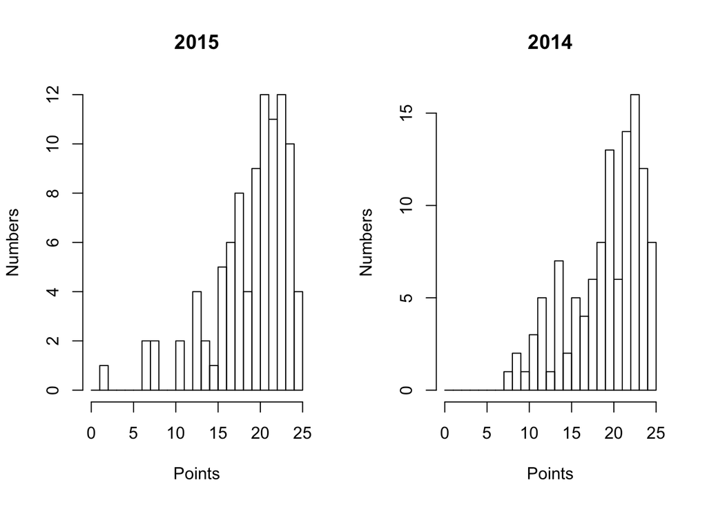

```r
par(mfrow=c(1,2))
hist(rt5$RT, breaks=0:25, main=2015,
     xlab="Points", ylab="Numbers")
hist(rt4$RT, breaks=0:25, main=2014,
     xlab="Points", ylab="Numbers")
```

```r
#par(mfrow=c(1,1))
```

箱ひげ図での年度比較。2015年度、2014年度

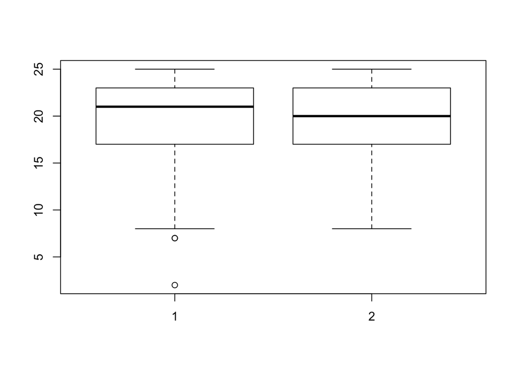

```r
# 左：2015年度、右：2014年度
boxplot(rt5$RT, rt4$RT)
```

### 2.2.3 総点結果

ヒストグラムで表示。

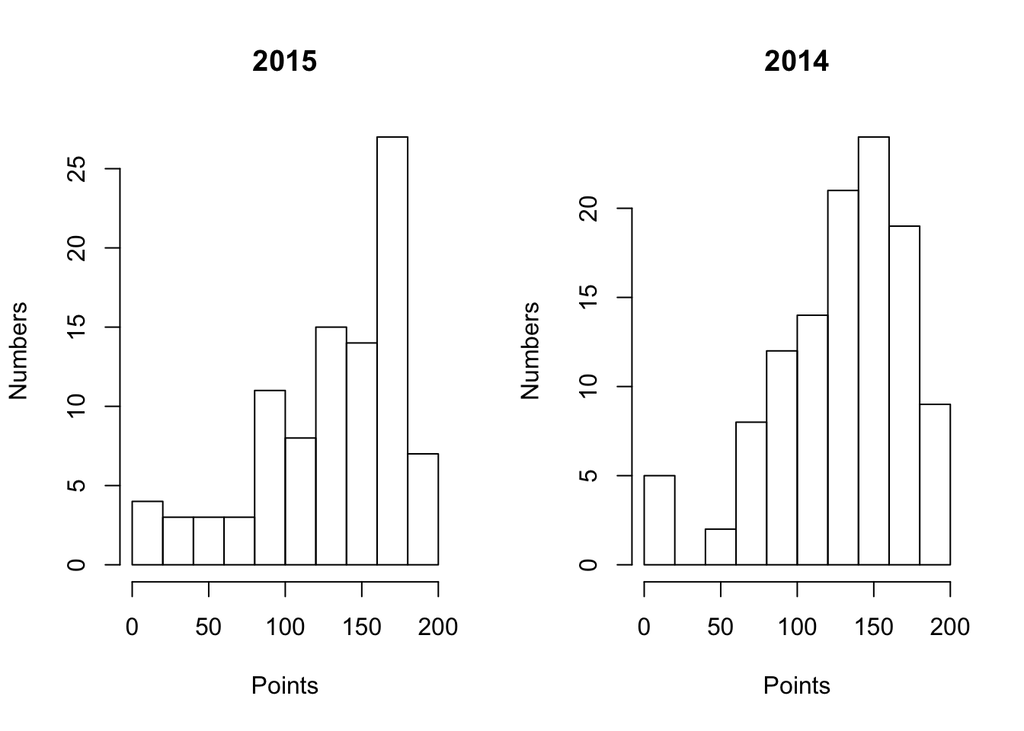

```r
par(mfrow=c(1,2))
hist(rt5$Total, main=2015,
     xlab="Points", ylab="Numbers")
hist(rt4$Total, main=2014,
     xlab="Points", ylab="Numbers")
```

```r
#par(mfrow=c(1,1))
```

箱ひげ図での年度比較。2015年度、2014年度

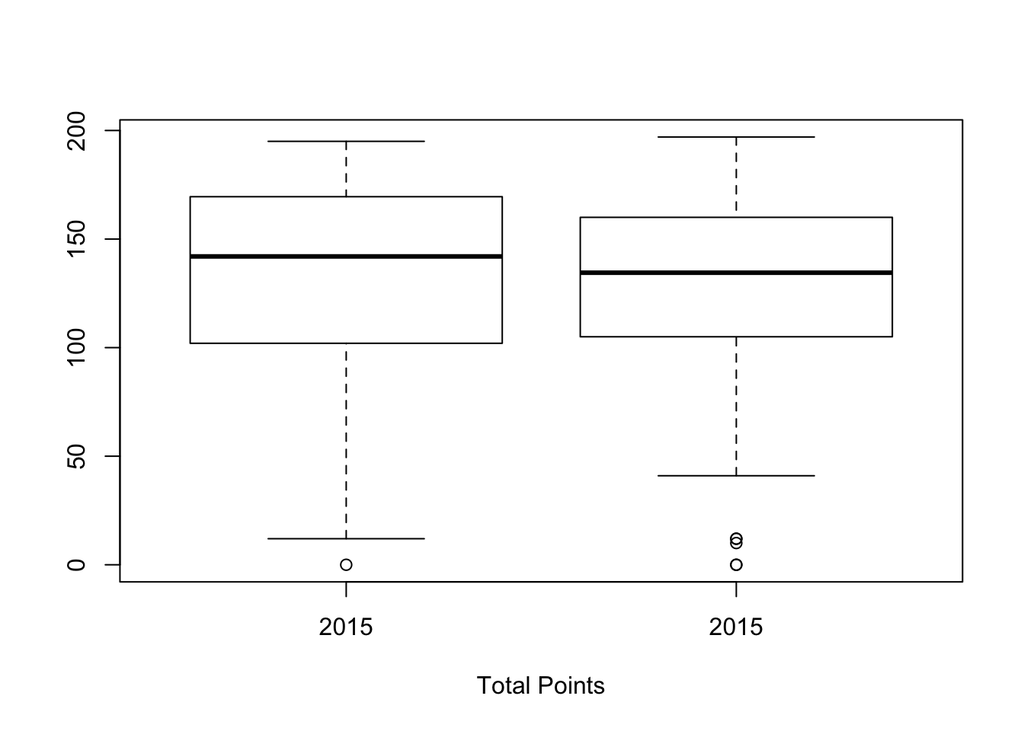

```r
# 左：2015年度、右：2014年度
boxplot(rt5$Total, rt4$Total, names=c("2015", "2015"), xlab="Total Points")
```

### 2.2.4 期末試験結果

ヒストグラムで表示。

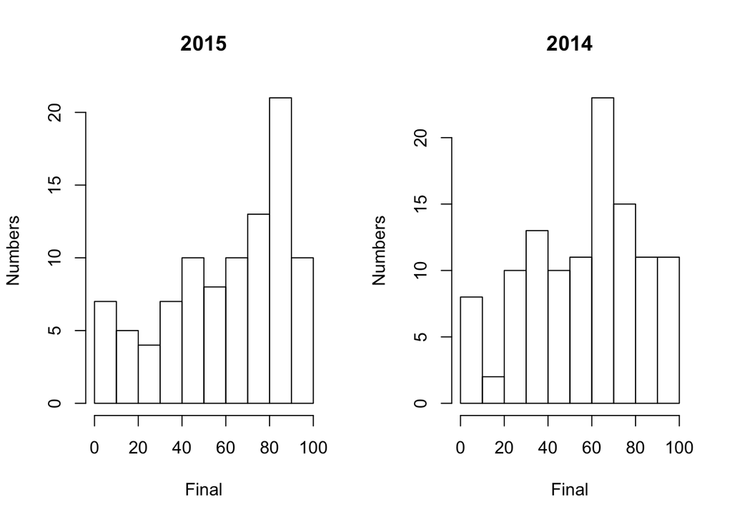

```r
par(mfrow=c(1,2))
hist(rt5$Final, main=2015,
     xlab="Final", ylab="Numbers")
hist(rt4$Final, main=2014,
     xlab="Final", ylab="Numbers")
```

```r
#par(mfrow=c(1,1))
```

箱ひげ図での年度比較。2015年度、2014年度

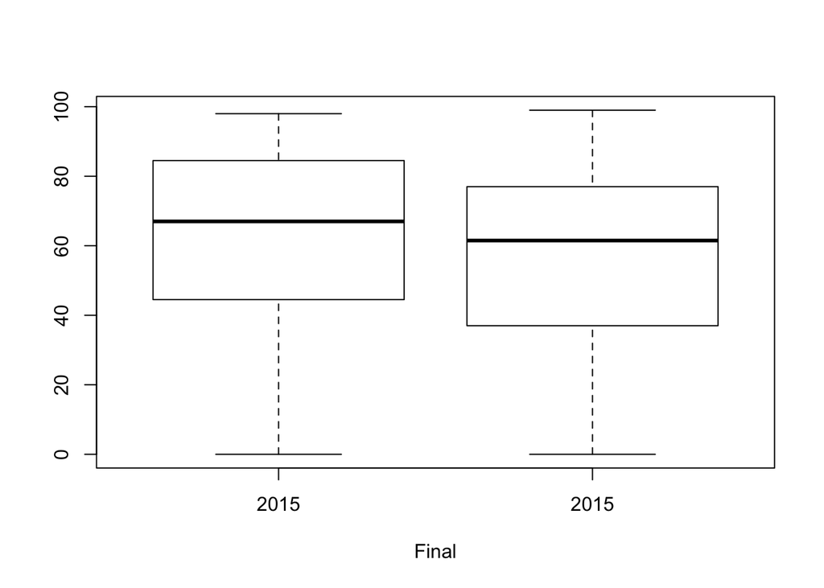

```r
# 左：2015年度、右：2014年度
boxplot(rt5$Final, rt4$Final, names=c("2015", "2015"), xlab="Final")
```

### 2.2.5 Research Test の各項目ごとの比較

#### 2.2.5.1 ID 別

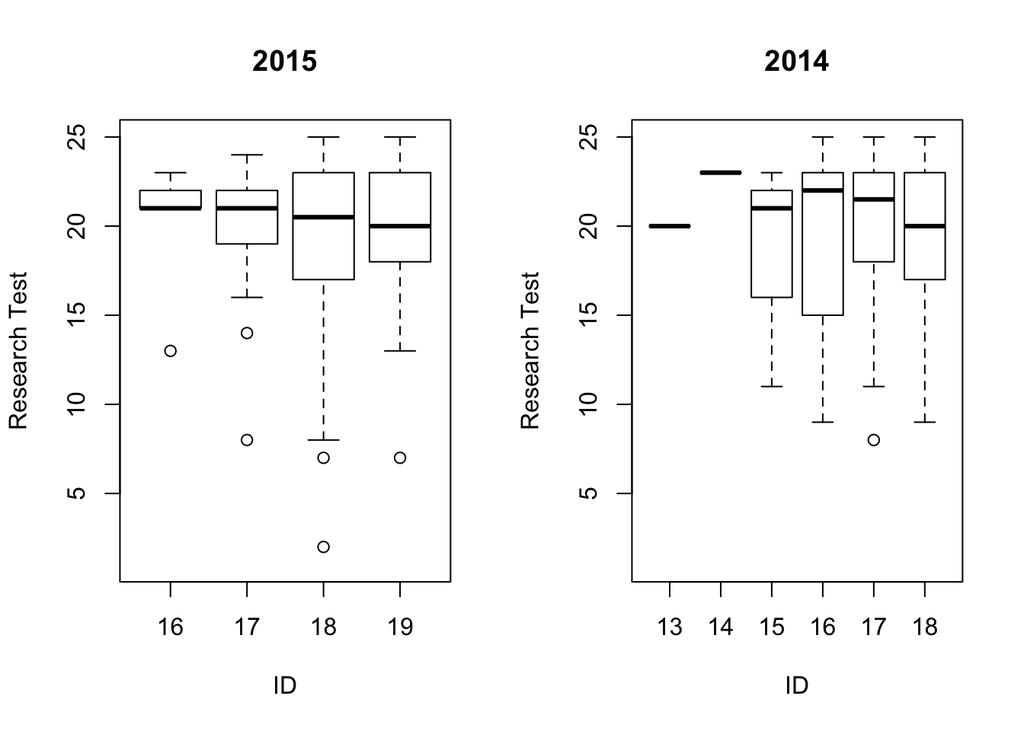

```r
par(mfrow=c(1,2))
boxplot(rt5$RT~rt5$ID2, xlab = "ID", ylab = "Research Test", main=2015, ylim=range(1:25))
boxplot(rt4$RT~rt4$ID2, xlab = "ID", ylab = "Research Test", main=2014, ylim=range(1:25))
```

もう少し適切な記述統計が必要

#### 2.2.5.2 日本の高校での数学履修科目数別

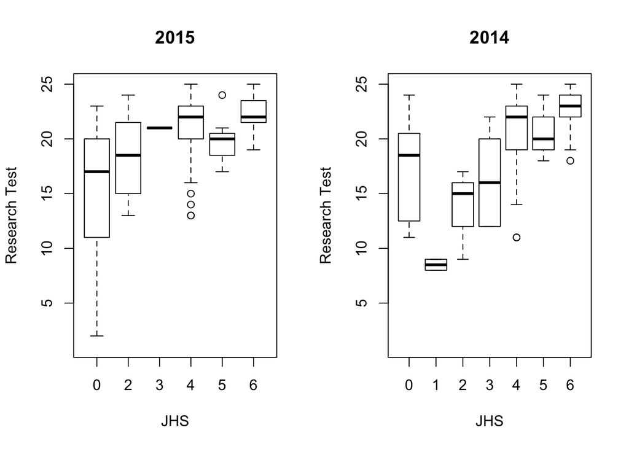

```r
par(mfrow=c(1,2))
boxplot(rt5$RT~rt5$JHS, xlab = "JHS", ylab = "Research Test", main=2015, ylim=range(1:25))
boxplot(rt4$RT~rt4$JHS, xlab = "JHS", ylab = "Research Test", main=2014, ylim=range(1:25))
```

新しい学習指導要領で科目数が変化しており、学生は両システムが混在。履修科目数は、1または２科目、３または４科目、５または６科目などとしたほうが適切。0は主として、９月生であるが、高等学校卒業認定試験合格者や、記載しないものなども含まれている。

### 2.2.6 総点と Research Test の散布図

弱い相関がみられる。感覚的なものであるが、コースデザイン的には、この程度が、この程度が適切だと思われる。努力が報われかつ力も発揮できる。

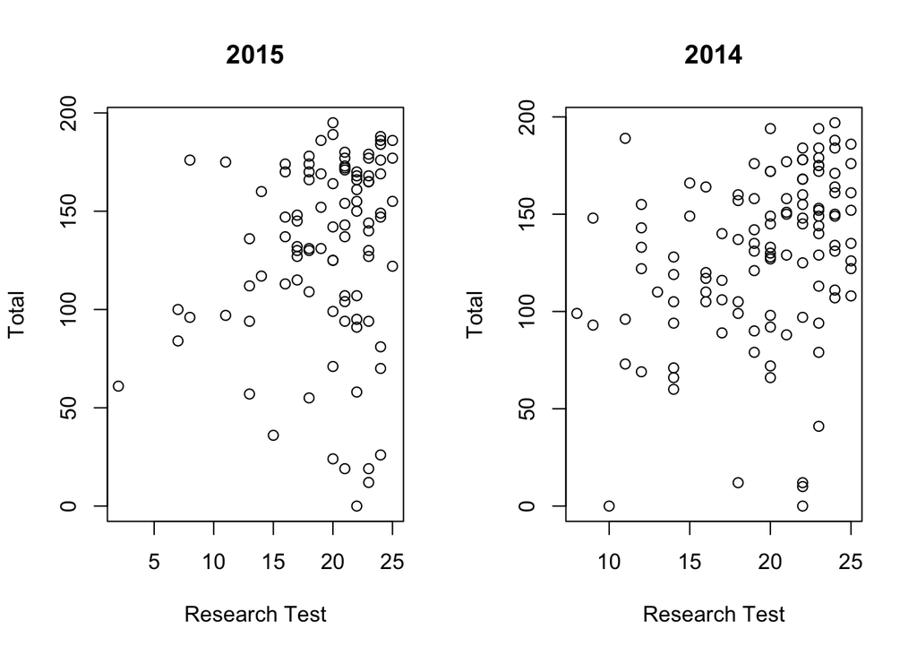

```r
par(mfrow=c(1,2))
plot(rt5$RT,rt5$Total, xlab = "Research Test", ylab = "Total", main=2015)
plot(rt4$RT,rt4$Total, xlab = "Research Test", ylab = "Total", main=2014)
```

### 2.2.7 総点と Research Test の相関

```r
par(mfrow=c(1,2))
cor.test(rt5$Total,rt5$RT)
```

```
##
##  Pearson's product-moment correlation
##
## data:  rt5$Total and rt5$RT
## t = 1.5371, df = 93, p-value = 0.1277
## alternative hypothesis: true correlation is not equal to 0
## 95 percent confidence interval:
##  -0.04559025  0.34790551
## sample estimates:
##      cor
## 0.157399
```

```r
cor.test(rt4$Total,rt4$RT)
```

```
##
##  Pearson's product-moment correlation
##
## data:  rt4$Total and rt4$RT
## t = 3.4681, df = 112, p-value = 0.0007446
## alternative hypothesis: true correlation is not equal to 0
## 95 percent confidence interval:
##  0.1352424 0.4684941
## sample estimates:
##       cor
## 0.3114114
```

### 2.2.8 総点と日本の高校での数学履修科目数

相関はとっていないが、以下の箱ヒゲ図からも、強い相関はみて取れない。適切なレベルと思われる。あとで述べるが、2015年度は、９月生の多様性が大きい。しかし、大きな差異は、あまりみられない。どの程度詳細に分析するか躊躇もあり、この程度としている。

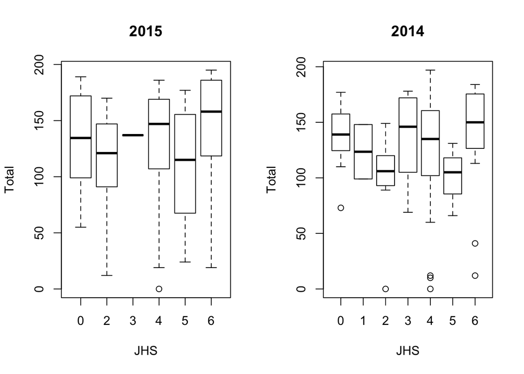

```r
par(mfrow=c(1,2))
boxplot(rt5$Total~rt5$JHS, xlab = "JHS", ylab = "Total", main=2015)
boxplot(rt4$Total~rt4$JHS, xlab = "JHS", ylab = "Total", main=2014)
```

### 2.2.9 期末試験の点と Research Test の散布図、相関

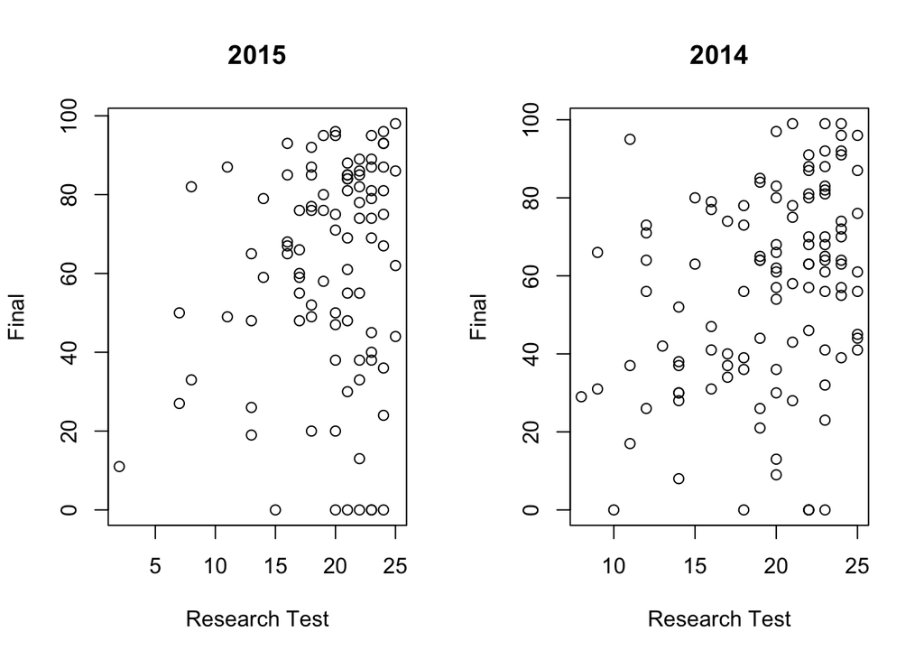

```r
par(mfrow=c(1,2))
plot(rt5$RT,rt5$Final, xlab = "Research Test", ylab = "Final", main=2015)
plot(rt4$RT,rt4$Final, xlab = "Research Test", ylab = "Final", main=2014)
```

```r
#par(mfrow=c(1,1))
cor.test(rt5$Final,rt5$RT)
```

```
##
##  Pearson's product-moment correlation
##
## data:  rt5$Final and rt5$RT
## t = 1.6542, df = 93, p-value = 0.1015
## alternative hypothesis: true correlation is not equal to 0
## 95 percent confidence interval:
##  -0.03362759  0.35839267
## sample estimates:
##       cor
## 0.1690612
```

```r
cor.test(rt4$Final,rt4$RT)
```

```
##
##  Pearson's product-moment correlation
##
## data:  rt4$Final and rt4$RT
## t = 3.3566, df = 112, p-value = 0.001078
## alternative hypothesis: true correlation is not equal to 0
## 95 percent confidence interval:
##  0.1253877 0.4606328
## sample estimates:
##       cor
## 0.3023306
```

### 2.2.10 期末試験と日本の高校での数学履修科目数

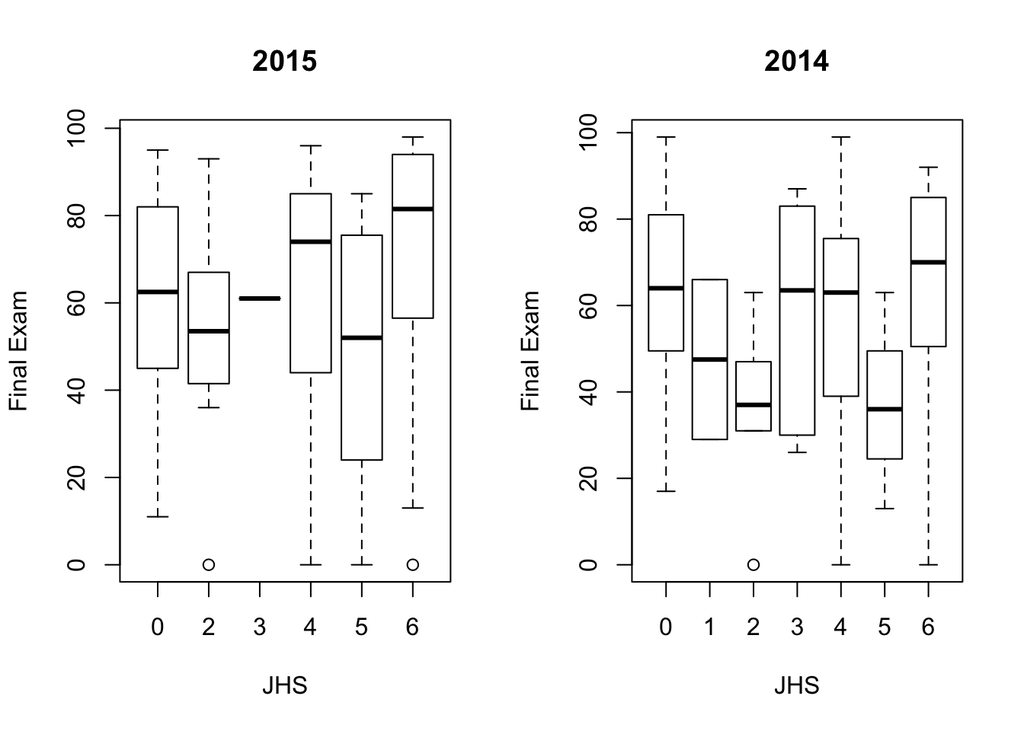

```r
par(mfrow=c(1,2))
boxplot(rt5$Final~rt5$JHS, xlab = "JHS", ylab = "Final Exam", main=2015)
boxplot(rt4$Final~rt4$JHS, xlab = "JHS", ylab = "Final Exam", main=2014)
```

他にも様々な統計的データを簡単に計算、記載できるが、この程度である目的は達していると思われる。多様性の配慮が必要であることと、コースデザインによって、そのコースでの学びが評価できることである。

## 2.3 一年生のみの分析

### 2.3.1 ELA のクラスで分析ができるように、データを整備

ELA のクラス（Stream 1, 2, 3, 4）が書かれていない、9月生に、0 を割り当てる。 また、2015年、2014年4月時点での、Stream 毎の人数をデータフレームとする。

```r
fr5$ELA[is.na(fr5$ELA)]<-0
fr4$ELA[is.na(fr4$ELA)]<-0
st5<-data.frame(0:4, c(94,20,85,349,122))
st4<-data.frame(0:4, c(47,19,78,323,112))
names(st5)<-c("ELA","NUM")
names(st4)<-c("ELA","NUM")
```

### 2.3.2 Enrolled Students According to Streams

登録人数と、1年生全体での数を記す

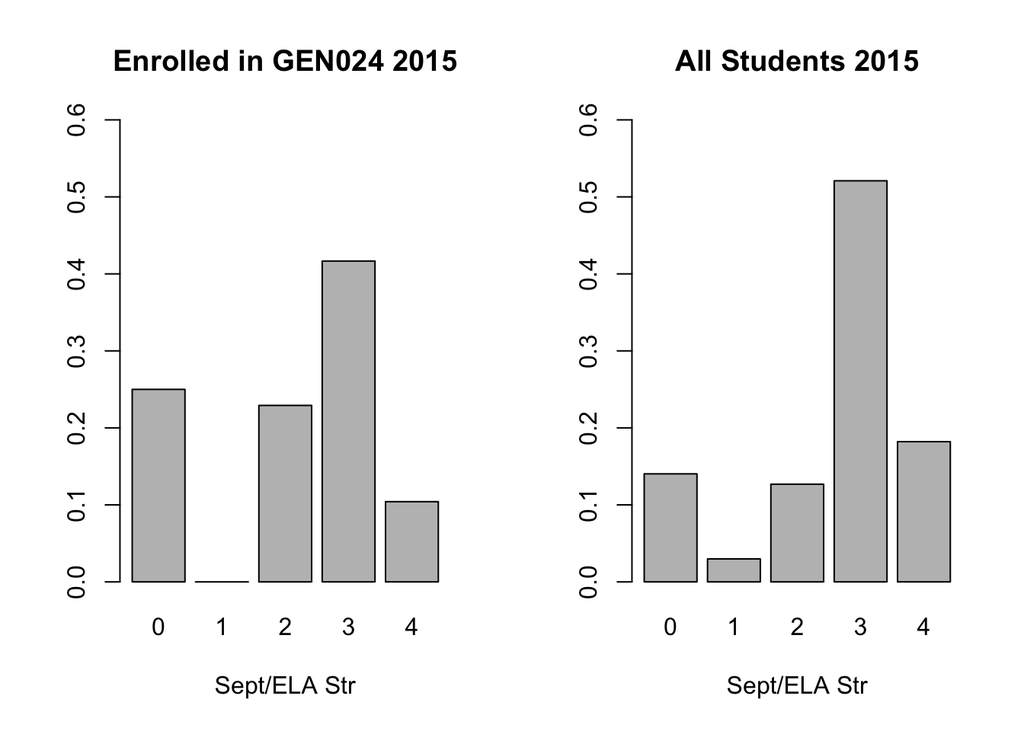

```r
par(mfrow=c(1,2))
ela5<-table(factor(fr5$ELA, 0:4))
barplot(ela5/sum(ela5), xlab="Sept/ELA Str", main="Enrolled in GEN024 2015", ylim=c(0.0,0.6))
st50 <- st5
st50$NUM <- st50$NUM/sum(st50$NUM)
barplot(st50$NUM, names.arg=st50$ELA, xlab="Sept/ELA Str", main="All Students 2015", ylim=c(0.0,0.6))
```

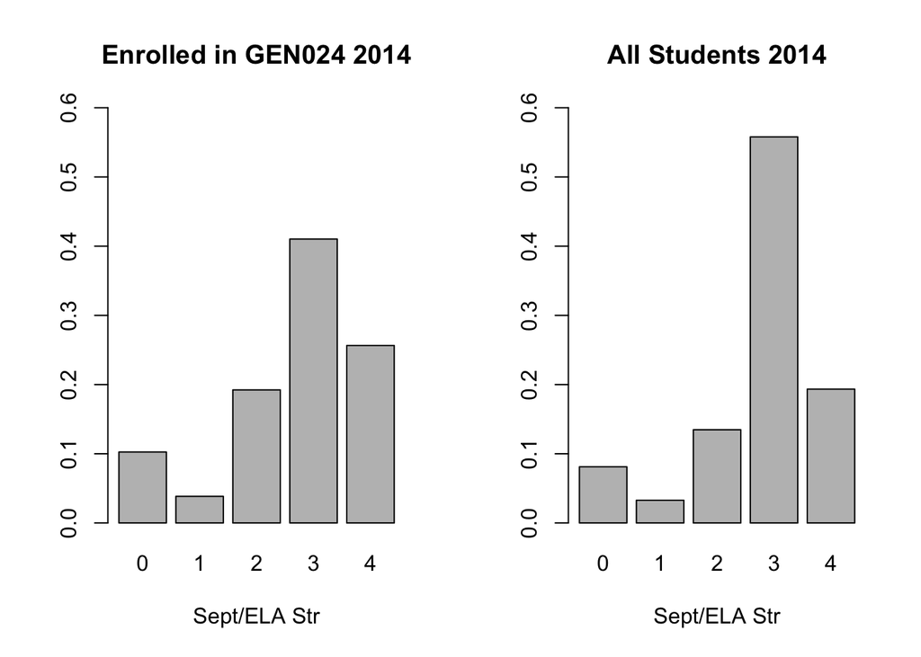

```r
#ela5; st5

ela4<-table(factor(fr4$ELA, 0:4)) #; sum(ela4)#ela4/sum(ela4[2,1:4])
barplot(ela4/sum(ela4), xlab="Sept/ELA Str", main="Enrolled in GEN024 2014", ylim=c(0.0,0.6))
st40 <- st4
st40$NUM <- st40$NUM/sum(st40$NUM)
barplot(st40$NUM, names.arg=st40$ELA, xlab="Sept/ELA Str", main="All Students 2014", ylim=c(0.0,0.6))
```

```r
#ela4; st4
```

2014年度「J/E」では、0, 4 が多く、2015年度「E/J」では0,2 が多く4が少ない